# QVC Analysis

- 전처리 과정은 Jupyter 메모리상 중간에 되지를 않게 되어 .R 내용을 확인
- [Data_Handling](https://github.com/byungjun0689/DataScience/blob/master/1.%20Portfolio/2.%20QVC/1.%20HandlingData.R)
- [Making OrderData](https://github.com/byungjun0689/DataScience/blob/master/1.%20Portfolio/2.%20QVC/2.%20making_order.R)
- [Clustering](https://github.com/byungjun0689/DataScience/blob/master/1.%20Portfolio/2.%20QVC/3.%20Clustering.R)
- [Recommand System](https://github.com/byungjun0689/DataScience/blob/master/1.%20Portfolio/2.%20QVC/4.%20Recommand%20System.R)

## 발표 자료

[PPT](https://github.com/byungjun0689/DataScience/tree/master/1.%20Portfolio/2.%20QVC/QVC_Challenge.pptx)

### 필요한 파일.

- Customer master2.csv
- order_data.csv
- product.csv
- timezone.csv
- zipcode.csv
- Product airtime.csv
- pre_order_data.csv
- *.txt 파일

```r
library(stringr)
library(arules)
library(dplyr)
library(maps)
library(ggplot2)
library(ggmap)
library(gridExtra)
library(reshape2)
library(arulesSequences)
library(lubridate)
```

```r
theme_set(theme_gray(base_size = 13))
```

## Data Load

```r
customer <- read.csv("data/Customer master2.csv")
customer$SHOPPER_SEGMENT_CODE <- as.factor(customer$SHOPPER_SEGMENT_CODE)
```

```r
head(customer)
```

|  | STATE | ZIP_CODE | CUSTOMER_NBR | SHOPPER_SEGMENT_CODE | city | latitude | longitude | timezone |
| --- | --- | --- | --- | --- | --- | --- | --- | --- |
| 1 | AK | 99501 | 442649 | 2 | Anchorage | 61.216799 | -149.87828 | US/Alaska |
| 2 | AK | 99501 | 657615 | 3 | Anchorage | 61.216799 | -149.87828 | US/Alaska |
| 3 | AK | 99501 | 315353 | 1 | Anchorage | 61.216799 | -149.87828 | US/Alaska |
| 4 | AK | 99501 | 235837 | 2 | Anchorage | 61.216799 | -149.87828 | US/Alaska |
| 5 | AK | 99502 | 516194 | 3 | Anchorage | 61.153693 | -149.95932 | US/Alaska |
| 6 | AK | 99502 | 224909 | 0 | Anchorage | 61.153693 | -149.95932 | US/Alaska |

```r
order_df <- read.csv("data/order_data.csv", stringsAsFactors = F)
order_df$SHOPPER_SEGMENT_CODE[is.na(order_df$SHOPPER_SEGMENT_CODE)] <- 0
order_df$SHOPPER_SEGMENT_CODE <- as.factor(order_df$SHOPPER_SEGMENT_CODE)
```

```r
product <- read.csv("data/Product master2.csv", stringsAsFactor = F)
```

```r
zip <- read.csv("data/zipcode.csv", stringsAsFactors = F)
```

# Data 확인.

## 1. 고객 분포도. Zip Code 별 고객 분포도.

```r
v_customer <- customer %>% group_by(ZIP_CODE) %>% summarize(cnt = n()) %>% filter(cnt > 5)
v_customer <- merge(v_customer,zip[,c(1,3:5)],by.x="ZIP_CODE",by.y="zip")
```

```r
head(v_customer)
```

|  | ZIP_CODE | cnt | state | latitude | longitude |
| --- | --- | --- | --- | --- | --- |
| 1 | 1001 | 8 | MA | 42.07061 | -72.62029 |
| 2 | 1007 | 6 | MA | 42.278424 | -72.411 |
| 3 | 1013 | 9 | MA | 42.161492 | -72.60316 |
| 4 | 1020 | 9 | MA | 42.175992 | -72.57265 |
| 5 | 1027 | 6 | MA | 42.27279 | -72.68677 |
| 6 | 1028 | 8 | MA | 42.066795 | -72.5102 |

### 지도 그리기

```r
options(repr.plot.width=5, repr.plot.height=5)
```

[figure not shown]

```r
map<-get_map(location='united states', zoom=4, maptype = "terrain",
             source='google',color='color')

ggmap(map) + geom_point(
  aes(x=longitude, y=latitude, show_guide = TRUE, colour=cnt, size=cnt),
  data=v_customer, alpha=1,na.rm = T)  +
  scale_color_gradient(low="beige", high="blue")
```

### 지도그리기 2

```r
options(repr.plot.width=5, repr.plot.height=3)
```

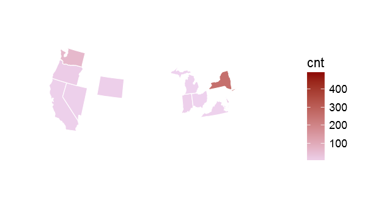

```r
us <- map_data("state")
city <- customer %>% group_by(city) %>% summarize(cnt = n())
city <- city %>% mutate(avg = cnt/mean(cnt))
city$city <- tolower(city$city)

gg <- ggplot()
gg <- gg + geom_map(data=us, map=us,
                    aes(x=long, y=lat, map_id=region),
                    fill="#ffffff", color="#ffffff", size=0.25)

gg <- gg + geom_map(data=city, map=us,
                    aes(fill=cnt, map_id=city),
                    color="#ffffff", size=0.25)
gg <- gg + scale_fill_continuous(low='thistle2', high='darkred',
                                 guide='colorbar')
gg <- gg + labs(x=NULL, y=NULL)
gg <- gg + coord_map("albers", lat0 = 39, lat1 = 45)
gg <- gg + theme(panel.border = element_blank())
gg <- gg + theme(panel.background = element_blank())
gg <- gg + theme(axis.ticks = element_blank())
gg <- gg + theme(axis.text = element_blank())
gg
```

## timezone 별 고객 분포도

```r
options(repr.plot.width=7, repr.plot.height=3)
```

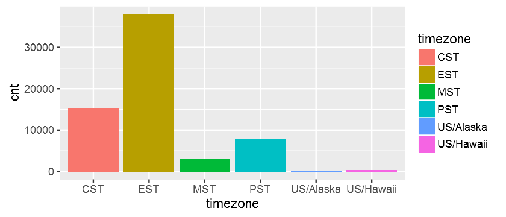

```r
timezone_customer <- customer %>% group_by(timezone) %>% summarize(cnt=n())
ggplot(timezone_customer,aes(x=timezone,y=cnt,fill=timezone)) + geom_bar(stat="identity")
```

## 2. State 별 고객 분포

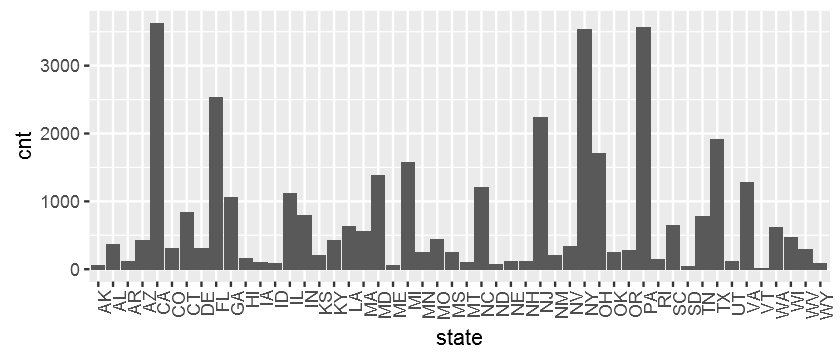

```r
state_number <- v_customer %>% group_by(state) %>% summarize(cnt = sum(cnt)) %>% arrange(desc(cnt))
ggplot(v_customer, aes(x=state,y=cnt)) + geom_bar(stat="identity") + theme(axis.text.x = element_text(angle = 90, hjust = 1))
```

## 3. State 별 Segment 별 고객 분포

```r
customer$SHOPPER_SEGMENT_CODE[is.na(customer$SHOPPER_SEGMENT_CODE)] <- 0
customer$SHOPPER_SEGMENT_CODE <- factor(customer$SHOPPER_SEGMENT_CODE)
seg_customer <- customer
```

```r
names(seg_customer)[4] <- "CODE"
```

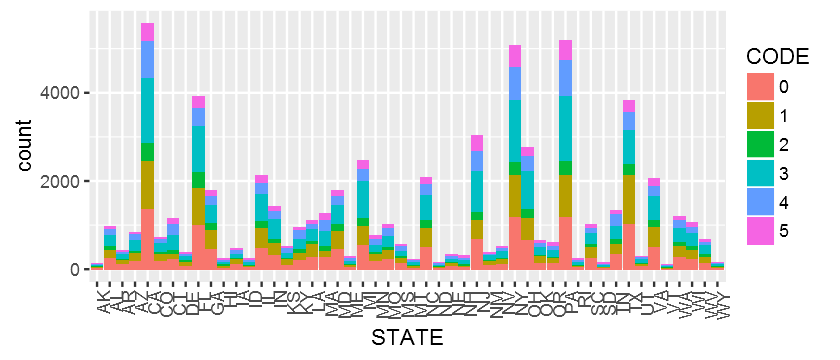

```r
ggplot(seg_customer,aes(x=STATE,fill=CODE)) + geom_bar() + theme(axis.text.x = element_text(angle = 90, hjust = 1))
```

## 4. segment 별 고객 분포

```r
segment_customer <- customer %>% group_by(SHOPPER_SEGMENT_CODE) %>% summarize(cu_cnt = n()) %>% mutate(prob = round((cu_cnt/sum(cu_cnt)),2)*100)
segment_customer$SHOPPER_SEGMENT_CODE[is.na(segment_customer$SHOPPER_SEGMENT_CODE)] <- 0
```

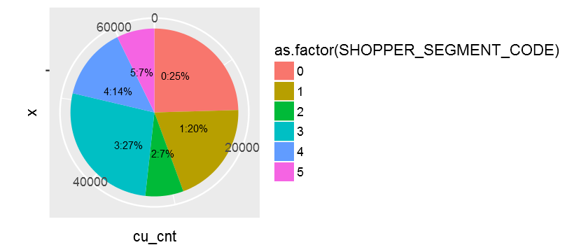

```r
bp<- ggplot(segment_customer, aes(x="", y=cu_cnt, fill=as.factor(SHOPPER_SEGMENT_CODE)))+
  geom_bar(width = 1, stat = "identity")
pie <- bp + coord_polar("y", start=0)
# scale_fill_brewer("Blues") + blank_theme +
pie +
  #theme(axis.text.x=element_blank())+
  geom_text(aes(y = cu_cnt/3 + c(0, cumsum(cu_cnt)[-length(cu_cnt)]),
                label = paste0(SHOPPER_SEGMENT_CODE,":",prob,"%")), size=3)
```

## 5. segment 별 구매 횟수

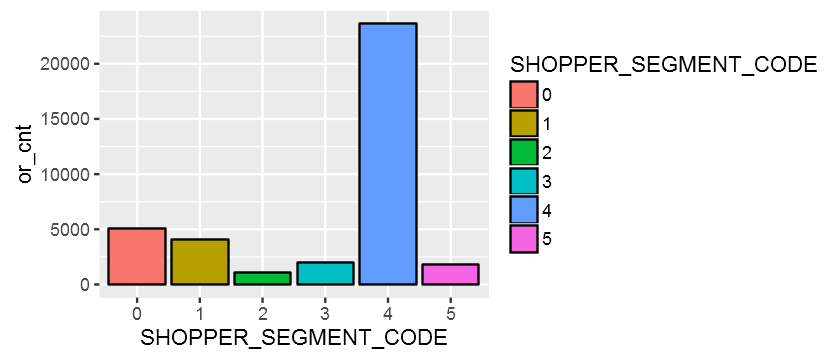

```r
segment_order <- order_df %>% group_by(SHOPPER_SEGMENT_CODE) %>% summarize(or_cnt=n())
segment_order$percent <- round(prop.table(segment_order$or_cnt),2)

ggplot(segment_order,aes(x=SHOPPER_SEGMENT_CODE,y=or_cnt,fill=SHOPPER_SEGMENT_CODE)) + geom_bar(stat="identity",colour="black")
```

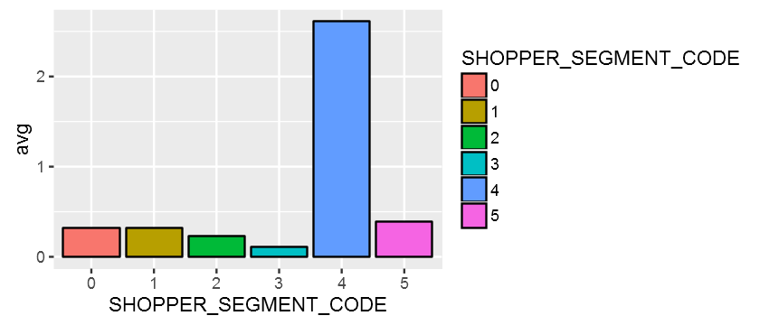

```r
segment_cus_order <- order_df %>% distinct(CUSTOMER_NBR,SHOPPER_SEGMENT_CODE) %>% group_by(SHOPPER_SEGMENT_CODE) %>% summarize(or_cnt=n())
 # 합쳐서
seg <- merge(segment_customer,segment_order,by="SHOPPER_SEGMENT_CODE")
seg <- seg %>% mutate(avg = round(or_cnt/cu_cnt,2))
ggplot(seg,aes(x=SHOPPER_SEGMENT_CODE,y=avg,fill=SHOPPER_SEGMENT_CODE)) + geom_bar(stat="identity",colour="black")
```

## 5.2 월별 판매 수

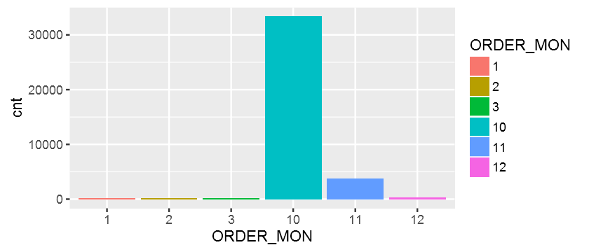

```r
#  월별 판매 수
mon_order <- order_df %>% group_by(ORDER_MON) %>% summarize(cnt =n())
mon_order$ORDER_MON <- as.factor(mon_order$ORDER_MON)
mon_order$per <- round(prop.table(mon_order$cnt),2) * 100
ggplot(data=mon_order,aes(x=ORDER_MON,y=cnt,fill=ORDER_MON)) +geom_bar(stat="identity")
```

## 6. 요일별 주문 Count

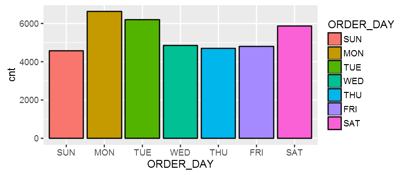

```r
v_day <- order_df %>% group_by(ORDER_DAY) %>% summarize(cnt=n())
v_day$ORDER_DAY = factor(v_day$ORDER_DAY,labels=c("SUN","MON","TUE","WED","THU","FRI","SAT"),ordered=TRUE)
ggplot(v_day, aes(x=ORDER_DAY,y=cnt,fill=ORDER_DAY)) + geom_bar(stat="identity",colour="black")
```

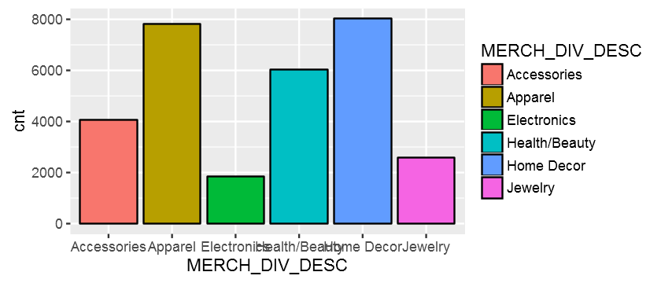

```r
order_per_cate <- order_df %>% group_by(MERCH_DIV_DESC) %>% summarize(cnt = n()) %>% arrange(desc(cnt))
ggplot(head(order_per_cate), aes(x=MERCH_DIV_DESC,y=cnt,fill=MERCH_DIV_DESC)) + geom_bar(stat="identity",colour="black")
```

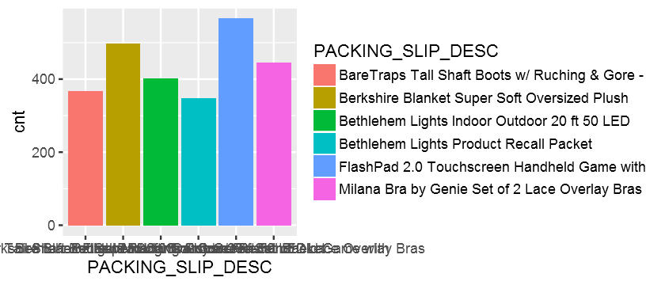

```r
order_per_product <- order_df %>% group_by(PACKING_SLIP_DESC) %>% summarize(cnt = n()) %>% arrange(desc(cnt))
ggplot(head(order_per_product), aes(x=PACKING_SLIP_DESC,y=cnt,fill=PACKING_SLIP_DESC)) + geom_bar(stat="identity")
```

## 9. 시간대별 판매 수

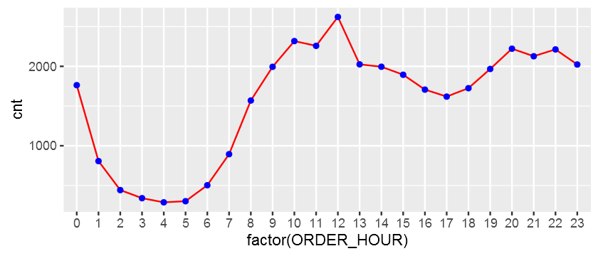

```r
v_time_cate <- order_df %>% group_by(ORDER_HOUR,MERCH_DIV_DESC) %>% summarize(cnt = n()) # 다른 데서 line plot으로 시간대별로 다르게 표현.
time_order <- v_time_cate %>% group_by(ORDER_HOUR) %>% summarize(cnt = sum(cnt))
ggplot(data=time_order, aes(x=factor(ORDER_HOUR), y=cnt,group=1)) + geom_line(color="red") + geom_point(color="blue")
```

## 10. Timezone 별 주문 횟수

```r
timezone_order <- order_df %>% group_by(timezone) %>% summarize(cnt = n()) %>% mutate(prob = round((cnt/sum(cnt)),3)*100)
timezone_order
```

|  | timezone | cnt | prob |
| --- | --- | --- | --- |
| 1 | CST | 8791 | 23.4 |
| 2 | EST | 21504 | 57.2 |
| 3 | MST | 1889 | 5 |
| 4 | PST | 5201 | 13.8 |
| 5 | US/Alaska | 151 | 0.4 |
| 6 | US/Hawaii | 82 | 0.2 |

```r
timezone_customer <- customer %>% group_by(timezone) %>% summarize(cnt=n())
timezone_cluster_customer <- customer %>% group_by(timezone,cluster) %>% summarize(cnt = n())
timezone_segment_customer <- customer %>% group_by(timezone,SHOPPER_SEGMENT_CODE) %>% summarize(cnt=n())

df_order_timezone <- data.frame(timezone = timezone_order$timezone, timezone_cnt = timezone_order$cnt)
df_customer_timezone <- data.frame(timezone = timezone_customer$timezone, customer_cnt = timezone_customer$cnt)
df_timezone <- merge(df_customer_timezone,df_order_timezone,by="timezone")
df_timezone <- df_timezone %>% mutate(per_order = round(timezone_cnt / customer_cnt,2))

timezone_order <- left_join(timezone_order,df_timezone[,c(1,4)])
```

```
Warning message:
In left_join_impl(x, y, by$x, by$y, suffix$x, suffix$y): joining factor and character vector, coercing into character vector
```

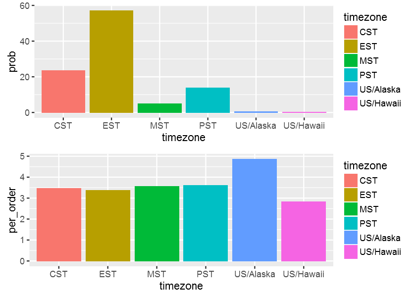

```r
options(repr.plot.height=5)
p1 <- ggplot(timezone_order,aes(x=timezone,y=prob,fill=timezone)) + geom_bar(stat="identity")
p2 <- ggplot(timezone_order,aes(x=timezone,y=per_order,fill=timezone)) + geom_bar(stat="identity")
gridExtra::grid.arrange(p1, p2)
```

## 11. Segmnet 요일 구매 패턴

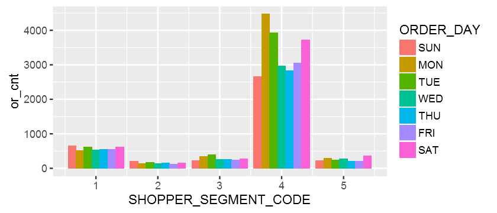

```r
options(repr.plot.height=3)
segment_mon_order <- order_df %>% group_by(SHOPPER_SEGMENT_CODE,ORDER_DAY) %>% summarize(or_cnt=n())
segment_mon_order$ORDER_DAY = factor(segment_mon_order$ORDER_DAY,labels=c("SUN","MON","TUE","WED","THU","FRI","SAT"),ordered=TRUE)
ggplot(segment_mon_order,aes(x=SHOPPER_SEGMENT_CODE,y=or_cnt,fill=ORDER_DAY)) + geom_bar(stat="identity",position="dodge")
```

## 12 . 광고 시청 유무에 따른 구매 및 전체 광고 흐름

```r
air_product <- read.csv("data/Product airtime.csv")
head(air_product)
```

|  | PRODUCT_ID | AIR_DATE | PRODUCT_AIRTIME_MINS | PRODUCT_START_TMS | PRODUCT_STOP_TMS |
| --- | --- | --- | --- | --- | --- |
| 1 | 2186 | 2012-10-16 0:00 | 0.38 | 2012-10-16 0:43 | 2012-10-16 0:44 |
| 2 | 2186 | 2012-10-16 0:00 | 5.08 | 2012-10-16 0:48 | 2012-10-16 0:53 |
| 3 | 2478 | 2012-10-16 0:00 | 0.5 | 2012-10-16 0:25 | 2012-10-16 0:26 |
| 4 | 2478 | 2012-10-16 0:00 | 12.53 | 2012-10-16 0:31 | 2012-10-16 0:43 |
| 5 | 6283 | 2012-10-16 0:00 | 0.43 | 2012-10-16 0:47 | 2012-10-16 0:48 |
| 6 | 6283 | 2012-10-16 0:00 | 4.73 | 2012-10-16 0:53 | 2012-10-16 0:58 |

### 12-1 시간대별 광고 전체

```r
air_product$PRODUCT_START_TMS  <- ymd_hm(air_product$PRODUCT_START_TMS)
air_product$PRODUCT_STOP_TMS  <- ymd_hm(air_product$PRODUCT_STOP_TMS)
air_product$AIR_DATE <- ymd_hm(air_product$AIR_DATE)
air_product$START_HOUR <- hour(air_product$PRODUCT_START_TMS)
air_product$STOP_HOUR <- hour(air_product$PRODUCT_STOP_TMS)
air_product$AIR_MON <- month(air_product$AIR_DATE)
head(air_product)
```

```
  PRODUCT_ID   AIR_DATE PRODUCT_AIRTIME_MINS   PRODUCT_START_TMS
1       2186 2012-10-16                 0.38 2012-10-16 00:43:00
2       2186 2012-10-16                 5.08 2012-10-16 00:48:00
3       2478 2012-10-16                 0.50 2012-10-16 00:25:00
4       2478 2012-10-16                12.53 2012-10-16 00:31:00
5       6283 2012-10-16                 0.43 2012-10-16 00:47:00
6       6283 2012-10-16                 4.73 2012-10-16 00:53:00
     PRODUCT_STOP_TMS START_HOUR STOP_HOUR AIR_MON
1 2012-10-16 00:44:00          0         0      10
2 2012-10-16 00:53:00          0         0      10
3 2012-10-16 00:26:00          0         0      10
4 2012-10-16 00:43:00          0         0      10
5 2012-10-16 00:48:00          0         0      10
6 2012-10-16 00:58:00          0         0      10
```

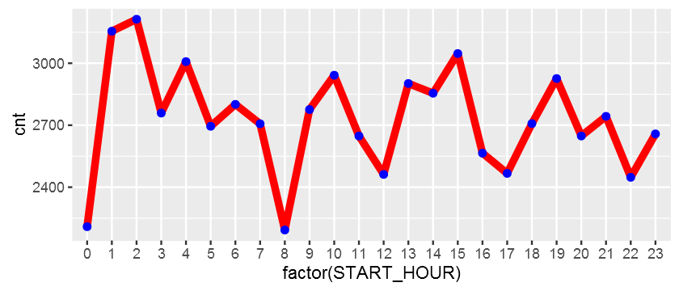

```r
total_air_hour <- air_product %>% group_by(START_HOUR) %>% summarize(cnt = n())
total_air_hour$type = "Total_Ad"
ggplot(total_air_hour,aes(x=factor(START_HOUR),y=cnt,group=2))  + geom_line(size = 2,color="red") + geom_point(color="blue",size=2)
```

```r
# 구매 제품의 방송 시간에 따른 구매 ####
tmp_df <- order_df[!is.na(order_df$AIR_DATE),]
air_time_order <- tmp_df %>% group_by(START_HOUR) %>% summarize(cnt = n())
```

```r
air_time_order$type="ConnectToSell"
```

```r
air_df <- rbind(total_air_hour,air_time_order)
air_df$START_HOUR <- factor(air_df$START_HOUR)
```

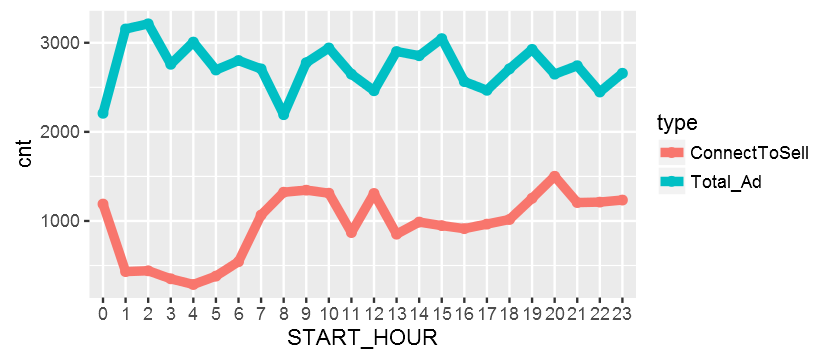

```r
ggplot(air_df,aes(x=START_HOUR,y=cnt)) + geom_line(aes(group=type,color=type),size = 2) + geom_point(aes(group=type,color=type),size = 2)
```

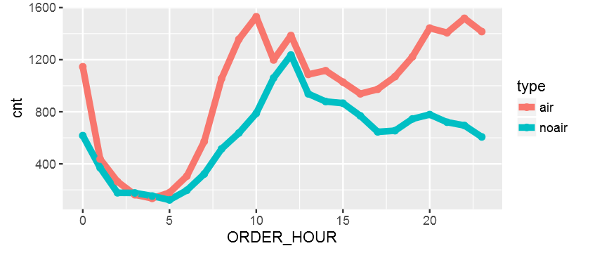

```r
# 광고를 본사람 vs 안본사람 시간대 비교 ####
air_order_df <- order_df[!is.na(order_df$AIR_DATE),]
no_air_order_df <- order_df[is.na(order_df$AIR_DATE),]

air_time_order <- air_order_df %>% group_by(ORDER_HOUR) %>% summarize(cnt=n())
no_air_time_order <- no_air_order_df %>% group_by(ORDER_HOUR) %>% summarize(cnt=n())

air_time_order$type="air"
no_air_time_order$type="noair"

compare_air <- rbind(air_time_order,no_air_time_order)
ggplot(compare_air,aes(x=ORDER_HOUR,y=cnt)) + geom_line(aes(group=type,color=type),size = 2) + geom_point(aes(group=type,color=type),size = 2)
```

### 전체 주문

- 0 ~ 6시 : 타 시간대 대비 광고량 대비 구매량이 현저히 적음
- 10 ~ 12시 : 주문 횟수 > 광고 횟수, 광고 ↑ : 구매 ↑
- 20 ~ 23시 : 광고 유무 -> 구매 영향도 높음, 매출 노ㅠ은 짧은 광고 시간의 상품 노출 필요

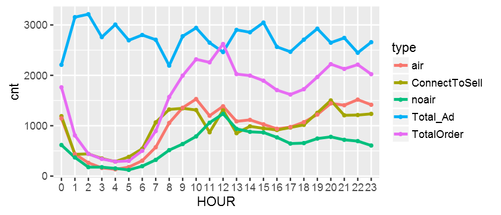

```r
names(air_df)[1] <- "HOUR"
names(compare_air)[1] <- "HOUR"

# 전체 주문 확보 ####
total_order <- order_df %>% group_by(ORDER_HOUR) %>% summarize(cnt=n())
names(total_order)[1] <- "HOUR"
total_order$type <- "TotalOrder"

tmp_df <- rbind(air_df,compare_air)
tmp_df <- rbind(tmp_df,total_order)
ggplot(tmp_df,aes(x=HOUR,y=cnt)) + geom_line(aes(group=type,color=type),size = 1) + geom_point(aes(group=type,color=type),size = 1)
```

# Answer the Questions

## 1. What is the next product a customer will buy in the next month given their previous buying behavior and product airtime?

- 제품의 경우 같은 Cluster 내 고객들의 구매 내역 중 내가 사지 않은 내역을 추천

```r
order_df <- read.csv("data/order_data_cluster.csv", stringsAsFactors = F)
customer <- read.csv("data/customer_with_cluster.csv",stringsAsFactors = F)
```

```r
order_df$SHOPPER_SEGMENT_CODE[is.na(order_df$SHOPPER_SEGMENT_CODE)] <- 0
order_df$SHOPPER_SEGMENT_CODE <- as.factor(order_df$SHOPPER_SEGMENT_CODE)
```

```r
for(i in 1:9){
  tmp_df <- order_df %>% filter(cluster==i)
  assign(paste0("cluster_",i),tmp_df)
}
```

```r
for(i in 1:9){
  tmp_df <- get(paste0("cluster_",i))
  tmp_df <- tmp_df %>% group_by(CUSTOMER_NBR,MERCH_DIV_DESC) %>% summarize(cnt = n()) %>% arrange(CUSTOMER_NBR)
  assign(paste0("cluster_cate_",i),as.data.frame(tmp_df))
}
```

```r
for(i in 1:9){
  tmp_df <- get(paste0("cluster_",i))
  tmp_df <- tmp_df %>% group_by(CUSTOMER_NBR,PRODUCT_ID) %>% summarize(cnt = n()) %>% arrange(CUSTOMER_NBR)
  assign(paste0("cluster_product_",i),as.data.frame(tmp_df))
}
```

### id별로 추천 가져오는 Function

### 1. Product 별

- Product 의 경우 한번 구매한 제품에 대해서 재 구매 확률이 낮으므로 Cluster별로 구매 했던 내역에서 고객이 주문한 내역을 제외한 빈도가 가장 높은 순으로 추천 하여 구매를 예측

```r
getProductRecommand <- function(x){
  custId <- x
  custCluster <- customer[customer$CUSTOMER_NBR==custId,]$cluster
  in_df <- get(paste0("cluster_product_",custCluster))
  in_product_list <- in_df[in_df$CUSTOMER_NBR==custId,]$PRODUCT_ID
  in_product_list <- as.data.frame(in_product_list)
  other_df <- in_df %>% filter(CUSTOMER_NBR!=custId) %>% group_by(PRODUCT_ID) %>% summarize(cnt = sum(cnt)) %>% arrange(desc(cnt))
  other_df <- as.data.frame(other_df)
  other_df$percent <- round(prop.table(other_df$cnt),2)
  result_df <- other_df %>% filter(!(PRODUCT_ID %in% in_product_list$in_producut_list))
  result_df <- left_join(result_df,product)
  names(in_product_list)[1] <- "PRODUCT_ID"
  in_product_list <- left_join(in_product_list,product)
  print(in_product_list[,c(1,2)])
  print(head(result_df[,c(1,4,2,3)]))
}
```

## 2. In what product category is a customer likely to buy their next product, given their previous buying behavior and product airtime?

- 카테고리의 경우 같은 카테고리를 구매할 가능성이 높으므로 연관분석을 통해 추천

### 2. Category

```r
getCateRecommand <- function(x){
  custId <- x
  custCluster <- customer[customer$CUSTOMER_NBR==custId,]$cluster
  if(length(custCluster)==0){
    return(0)
  }
  baskets <-  read_baskets(con  = paste0("data/item_cate_",custCluster,".txt"),sep = "#", info = c("sequenceID","eventID","SIZE"))
  baskets <- cspade(baskets, parameter = list(support = 0.0001), control = list(verbose = TRUE))
  baskets_df <- as(baskets, "data.frame")
  baskets_df <- baskets_df[order(baskets_df$support,decreasing = T),]
  baskets_df$sequence <- gsub(pattern = "<\\{\"","",baskets_df$sequence)
  baskets_df$sequence <- gsub(pattern = "\"\\}>","",baskets_df$sequence)
  baskets_df$sequence <- gsub(pattern = "\"","",baskets_df$sequence)
  last_df <- order_df[order_df$CUSTOMER_NBR==custId,] %>%
    arrange(desc(ORDER_DATES)) %>%
    select(MERCH_DIV_DESC)
  last_cate <- last_df$MERCH_DIV_DESC
  support_df <- baskets_df %>% filter(str_detect(sequence,last_cate))
  print(paste0(last_cate))
  print(head(support_df[-1,]))
}
```

```r
getRecommand <- function(cate,y){
  if(cate=="cate"){
    getCateRecommand(y)
  }else{
    getProductRecommand(y)
  }
}
```

```r
getRecommand("cate",1275)
```

```
parameter specification:
support : 1e-04
maxsize :    10
maxlen  :    10

algorithmic control:
bfstype  : FALSE
verbose  :  TRUE
summary  : FALSE
tidLists : FALSE

preprocessing ... 1 partition(s), 0.09 MB [0.66s]
mining transactions ... 0 MB [0.4s]
reading sequences ... [0.11s]

total elapsed time: 1.17s
[1] "Entertainment" "Health/Beauty" "Health/Beauty" "Health/Beauty"
[5] "Health/Beauty" "Health/Beauty"
                       sequence      support
2      Health/Beauty,Home Decor 0.0032706460
3 Health/Beauty,IQVC Divisional 0.0029980921
4         Health/Beauty,Apparel 0.0027255383
5     Accessories,Health/Beauty 0.0010902153
6         Health/Beauty,Jewelry 0.0008176615
7      Health/Beauty,Housewares 0.0008176615
```

```r
getRecommand("product",749351)
```

```
  PRODUCT_ID                               PACKING_SLIP_DESC
1       9887      Layers by Lizden Marvelush Smooth & Ribbed
2      11916  Milana Bra by Genie Set of 2 Lace Overlay Bras
3      32338          Set of 20 Faceted Droplet Ornaments by
4      44978     UltraFine Silver 8mm Reversible Diamond Cut
5      49825 Simply Stacks Sterling 4mm Round Peridot Solita
6      49826 Simply Stacks Sterling 4mm Round Pink Tourmalin
  PRODUCT_ID                              PACKING_SLIP_DESC cnt percent
1      61109    FlashPad 2.0 Touchscreen Handheld Game with  51    0.02
2      10811 BareTraps Tall Shaft Boots w/ Ruching & Gore -  42    0.01
3      11916 Milana Bra by Genie Set of 2 Lace Overlay Bras  40    0.01
4      32565   Berkshire Blanket Super Soft Oversized Plush  31    0.01
5      32612   Bethlehem Lights Indoor Outdoor 20 ft 50 LED  29    0.01
6       9887     Layers by Lizden Marvelush Smooth & Ribbed  26    0.01
```

## 3. What are the products and categories that sell better in a particular geographic, time zone, and customer segment?

### 3-1 particular geographic

```r
v3_1 <- order_df %>%
  group_by(STATE,PACKING_SLIP_DESC) %>%
  summarize(Pro_cnt=n()) %>%
  slice(which.max(Pro_cnt))
```

```r
v3_1_2 <- order_df %>% group_by(STATE,MERCH_DIV_DESC) %>% summarize(Category_cnt=n()) %>% slice(which.max(Category_cnt))
```

```r
head(v3_1)
```

|  | STATE | PACKING_SLIP_DESC | Pro_cnt |
| --- | --- | --- | --- |
| 1 | AK | Berkshire Blanket Super Soft Oversized Plush | 11 |
| 2 | AL | BareTraps Tall Shaft Boots w/ Ruching & Gore - | 8 |
| 3 | AR | Berkshire Blanket Super Soft Oversized Plush | 9 |
| 4 | AZ | WEN by Chaz Dean Fall Ginger Pumpkin | 7 |
| 5 | CA | Berkshire Blanket Super Soft Oversized Plush | 41 |
| 6 | CO | Berkshire Blanket Super Soft Oversized Plush | 12 |

```r
head(v3_1_2)
```

|  | STATE | MERCH_DIV_DESC | Category_cnt |
| --- | --- | --- | --- |
| 1 | AK | Home Decor | 34 |
| 2 | AL | Home Decor | 85 |
| 3 | AR | Apparel | 46 |
| 4 | AZ | Home Decor | 91 |
| 5 | CA | Apparel | 856 |
| 6 | CO | Home Decor | 132 |

## 3-2 Time Zone

```r
v3_3 <- order_df %>% group_by(timezone,PACKING_SLIP_DESC) %>% summarize(Hour_P_cnt=n()) %>% slice(which.max(Hour_P_cnt))
v3_4 <- order_df %>% group_by(timezone,MERCH_DIV_DESC) %>% summarize(Hour_C_cnt=n()) %>% slice(which.max(Hour_C_cnt))
```

```r
head(v3_3)
```

[output not shown]

```r
head(v3_4)
```

[output not shown]

### 3-3 Segment

```r
cs_prodcut <- order_df %>%
  group_by(SHOPPER_SEGMENT_CODE,PACKING_SLIP_DESC) %>%
  summarize(pro_cnt=n()) %>%
  slice(which.max(pro_cnt))
head(cs_prodcut)
```

|  | SHOPPER_SEGMENT_CODE | PACKING_SLIP_DESC | pro_cnt |
| --- | --- | --- | --- |
| 1 | 1 | FlashPad 2.0 Touchscreen Handheld Game with | 86 |
| 2 | 2 | Bethlehem Lights Product Recall Packet | 26 |
| 3 | 3 | Bethlehem Lights Product Recall Packet | 77 |
| 4 | 4 | FlashPad 2.0 Touchscreen Handheld Game with | 335 |
| 5 | 5 | Berkshire Blanket Super Soft Oversized Plush | 34 |
| 6 | NA | FlashPad 2.0 Touchscreen Handheld Game with | 82 |

```r
cs_category <- order_df %>%
  group_by(SHOPPER_SEGMENT_CODE,MERCH_DIV_DESC) %>%
  summarize(cate_cnt=n()) %>%
  slice(which.max(cate_cnt))
head(cs_category)
```

|  | SHOPPER_SEGMENT_CODE | MERCH_DIV_DESC | cate_cnt |
| --- | --- | --- | --- |
| 1 | 1 | Home Decor | 996 |
| 2 | 2 | Home Decor | 359 |
| 3 | 3 | Home Decor | 562 |
| 4 | 4 | Apparel | 6016 |
| 5 | 5 | Health/Beauty | 473 |
| 6 | NA | Home Decor | 1040 |

### 3-4 TimeZone & Segment Cross

```r
# 3. 타임존, 세그먼트별 잘팔리는 제품.
tzsg_product <- order_df %>% group_by(timezone,SHOPPER_SEGMENT_CODE,PACKING_SLIP_DESC) %>% summarize(tzsg_pro_cnt=n()) %>% slice(which.max(tzsg_pro_cnt))
tzsg_category <- order_df %>% group_by(timezone,SHOPPER_SEGMENT_CODE,MERCH_DIV_DESC) %>% summarize(tzsg_cate_cnt=n()) %>% slice(which.max(tzsg_cate_cnt))
tzsg_product$SHOPPER_SEGMENT_CODE[is.na(tzsg_product$SHOPPER_SEGMENT_CODE)] <- 0
tzsg_category$SHOPPER_SEGMENT_CODE[is.na(tzsg_category$SHOPPER_SEGMENT_CODE)] <- 0
```

```r
head(tzsg_category)
```

|  | timezone | SHOPPER_SEGMENT_CODE | MERCH_DIV_DESC | tzsg_cate_cnt |
| --- | --- | --- | --- | --- |
| 1 | CST | 1 | Home Decor | 257 |
| 2 | CST | 2 | Home Decor | 79 |
| 3 | CST | 3 | Home Decor | 123 |
| 4 | CST | 4 | Apparel | 1398 |
| 5 | CST | 5 | Health/Beauty | 108 |
| 6 | CST | 0 | Home Decor | 273 |

```r
tail(tzsg_category)
```

|  | timezone | SHOPPER_SEGMENT_CODE | MERCH_DIV_DESC | tzsg_cate_cnt |
| --- | --- | --- | --- | --- |
| 1 | US/Hawaii | 1 | Home Decor | 7 |
| 2 | US/Hawaii | 2 | Accessories | 1 |
| 3 | US/Hawaii | 3 | Entertainment | 3 |
| 4 | US/Hawaii | 4 | Apparel | 10 |
| 5 | US/Hawaii | 5 | Health/Beauty | 2 |
| 6 | US/Hawaii | 0 | Health/Beauty | 2 |

## 4. Is there a best time of day to sell a particular product or product category?

```r
product_per_hour <- order_df %>%
  group_by(PACKING_SLIP_DESC,ORDER_HOUR) %>%
  summarize(pro_cnt=n()) %>%
  slice(which.max(pro_cnt)) %>%
  filter(pro_cnt>10) %>% arrange(ORDER_HOUR)
```

```r
head(product_per_hour)
```

|  | PACKING_SLIP_DESC | ORDER_HOUR | pro_cnt |
| --- | --- | --- | --- |
| 1 | Berkshire Blanket Super Soft Oversized Plush | 0 | 132 |
| 2 | Duraflame 750W/1500W Electric Stove Heater with | 0 | 17 |
| 3 | FlashPad 2.0 Touchscreen Handheld Game with | 0 | 66 |
| 4 | INFOtainment Apple iPad Charging and Docking | 0 | 33 |
| 5 | Josie Maran Art of Giving 8-pc Argan Bath & | 0 | 20 |
| 6 | Judith Ripka Stainless Steel Chronograph Watch | 0 | 16 |

## 5.What is the brand affinity (personal connection with the brands QVC sells) for QVC’s different customer segments?

- 간단하게 답변한다면 Segment별로 좋아하는 Brand를 가지고 오면 된다.
- 하지만 각 브랜드별로 어떤 상관관계가 있고 구매를 촉진 시키는지 Cross Selling이 가능한지 여부를 확인해야한다.

```r
segment_brand <- order_df %>% group_by(SHOPPER_SEGMENT_CODE,BRAND_NAME) %>% summarize(cnt = n()) %>% arrange(SHOPPER_SEGMENT_CODE,desc(cnt))
segment_brand_max <- order_df %>% filter(BRAND_NAME!="Not Known" & BRAND_NAME!="N/A") %>% group_by(SHOPPER_SEGMENT_CODE,BRAND_NAME) %>% summarize(cnt = n()) %>% slice(which.max(cnt))
segment_brand_max$SHOPPER_SEGMENT_CODE[is.na(segment_brand_max$SHOPPER_SEGMENT_CODE)] <- 0
```

```r
segment_brand_max
```

|  | SHOPPER_SEGMENT_CODE | BRAND_NAME | cnt |
| --- | --- | --- | --- |
| 1 | 1 | WEN | 218 |
| 2 | 2 | Temp-tations | 46 |
| 3 | 3 | Denim & Co. | 107 |
| 4 | 4 | Denim & Co. | 1857 |
| 5 | 5 | WEN | 95 |
| 6 | 0 | Susan Graver | 246 |

### 브랜드별 상관관계

#### 상위 20개 브랜드

```r
count_brand <- order_df %>% group_by(BRAND_NAME) %>% summarize(cnt = n()) %>% arrange(desc(cnt)) %>% head(20)

brand_list <- count_brand$BRAND_NAME
brand_list <- as.data.frame(brand_list)
brand_rel <- order_df %>% filter(BRAND_NAME %in% brand_list$brand_list & BRAND_NAME != "Not Known" & BRAND_NAME != "N/A") %>% group_by(CUSTOMER_NBR,BRAND_NAME) %>% summarize(cnt = n())
brand_rel <- dcast(CUSTOMER_NBR ~ BRAND_NAME, data = brand_rel, value.var = "cnt")
brand_rel[is.na(brand_rel)] <- 0
brand_cor <- round(cor(brand_rel),2)
brand_cor <- as.data.frame(brand_cor)
```

```r
library(psych)
```

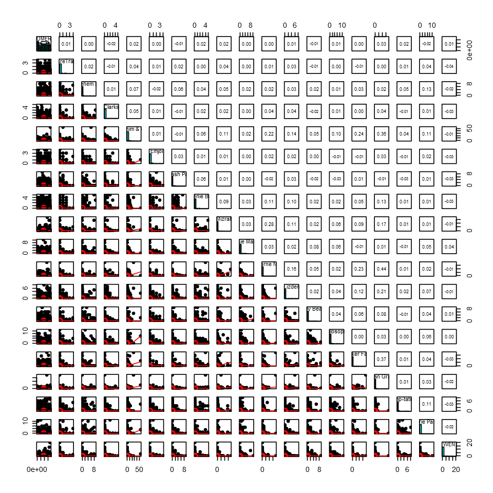

```r
options(repr.plot.width=8, repr.plot.height=8)
pairs.panels(brand_rel)
```

```r
brand_cor
```

|  | CUSTOMER_NBR | BareTraps | Bethlehem Lights | Clarks | Denim & Co. | Emjoi | Flash Pad | Genie Bra | Isaac Mizrahi Live! | Josie Maran | Liz Claiborne New York | Lizden | Mally Beauty | philosophy | Quacker Factory | Susan Graver | Temp-tations | Valerie Parr Hill | WEN |
| --- | --- | --- | --- | --- | --- | --- | --- | --- | --- | --- | --- | --- | --- | --- | --- | --- | --- | --- | --- |
| CUSTOMER_NBR | 1.00 | 0.01 | 0.00 | -0.02 | 0.02 | 0.00 | -0.01 | 0.02 | 0.02 | 0.00 | 0.00 | 0.01 | -0.01 | 0.01 | 0.00 | 0.03 | 0.02 | -0.02 | 0.01 |
| BareTraps | 0.01 | 1.00 | 0.02 | -0.01 | 0.04 | 0.01 | 0.02 | 0.00 | 0.04 | 0.00 | 0.01 | 0.03 | -0.01 | 0.00 | -0.01 | 0.00 | 0.01 | 0.04 | -0.04 |
| Bethlehem Lights | 0.00 | 0.02 | 1.00 | 0.01 | 0.07 | -0.02 | 0.06 | 0.04 | 0.05 | 0.02 | 0.02 | 0.03 | 0.02 | 0.01 | 0.03 | 0.02 | 0.05 | 0.13 | -0.02 |
| Clarks | -0.02 | -0.01 | 0.01 | 1.00 | 0.05 | 0.01 | -0.01 | 0.02 | 0.02 | 0.00 | 0.04 | 0.04 | -0.02 | 0.01 | 0.00 | 0.04 | -0.01 | 0.01 | -0.03 |
| Denim & Co. | 0.02 | 0.04 | 0.07 | 0.05 | 1.00 | 0.01 | -0.01 | 0.06 | 0.11 | 0.02 | 0.22 | 0.14 | 0.05 | 0.10 | 0.24 | 0.36 | 0.04 | 0.11 | -0.01 |
| Emjoi | 0.00 | 0.01 | -0.02 | 0.01 | 0.01 | 1.00 | 0.03 | 0.01 | 0.01 | 0.00 | 0.02 | 0.02 | 0.00 | -0.01 | -0.01 | 0.03 | -0.01 | 0.02 | -0.03 |
| Flash Pad | -0.01 | 0.02 | 0.06 | -0.01 | -0.01 | 0.03 | 1.00 | 0.06 | 0.01 | 0.00 | -0.02 | 0.03 | -0.02 | -0.03 | 0.01 | -0.01 | -0.03 | 0.01 | -0.03 |
| Genie Bra | 0.02 | 0.00 | 0.04 | 0.02 | 0.06 | 0.01 | 0.06 | 1.00 | 0.09 | 0.03 | 0.11 | 0.10 | 0.02 | 0.02 | 0.05 | 0.13 | 0.01 | 0.01 | -0.03 |
| Isaac Mizrahi Live! | 0.02 | 0.04 | 0.05 | 0.02 | 0.11 | 0.01 | 0.01 | 0.09 | 1.00 | 0.03 | 0.28 | 0.11 | 0.02 | 0.06 | 0.09 | 0.17 | 0.01 | 0.01 | -0.01 |
| Josie Maran | 0.00 | 0.00 | 0.02 | 0.00 | 0.02 | 0.00 | 0.00 | 0.03 | 0.03 | 1.00 | 0.03 | 0.02 | 0.08 | 0.06 | -0.01 | 0.01 | -0.01 | 0.05 | 0.04 |
| Liz Claiborne New York | 0.00 | 0.01 | 0.02 | 0.04 | 0.22 | 0.02 | -0.02 | 0.11 | 0.28 | 0.03 | 1.00 | 0.16 | 0.05 | 0.02 | 0.23 | 0.44 | 0.01 | 0.02 | -0.01 |
| Lizden | 0.01 | 0.03 | 0.03 | 0.04 | 0.14 | 0.02 | 0.03 | 0.10 | 0.11 | 0.02 | 0.16 | 1.00 | 0.02 | 0.04 | 0.12 | 0.21 | 0.02 | 0.07 | -0.01 |
| Mally Beauty | -0.01 | -0.01 | 0.02 | -0.02 | 0.05 | 0.00 | -0.02 | 0.02 | 0.02 | 0.08 | 0.05 | 0.02 | 1.00 | 0.04 | 0.06 | 0.08 | -0.01 | 0.04 | 0.01 |
| philosophy | 0.01 | 0.00 | 0.01 | 0.01 | 0.10 | -0.01 | -0.03 | 0.02 | 0.06 | 0.06 | 0.02 | 0.04 | 0.04 | 1.00 | 0.00 | 0.03 | 0.00 | 0.06 | 0.00 |
| Quacker Factory | 0.00 | -0.01 | 0.03 | 0.00 | 0.24 | -0.01 | 0.01 | 0.05 | 0.09 | -0.01 | 0.23 | 0.12 | 0.06 | 0.00 | 1.00 | 0.37 | 0.01 | 0.04 | -0.03 |
| Susan Graver | 0.03 | 0.00 | 0.02 | 0.04 | 0.36 | 0.03 | -0.01 | 0.13 | 0.17 | 0.01 | 0.44 | 0.21 | 0.08 | 0.03 | 0.37 | 1.00 | 0.01 | 0.03 | -0.02 |
| Temp-tations | 0.02 | 0.01 | 0.05 | -0.01 | 0.04 | -0.01 | -0.03 | 0.01 | 0.01 | -0.01 | 0.01 | 0.02 | -0.01 | 0.00 | 0.01 | 0.01 | 1.00 | 0.11 | -0.03 |
| Valerie Parr Hill | -0.02 | 0.04 | 0.13 | 0.01 | 0.11 | 0.02 | 0.01 | 0.01 | 0.01 | 0.05 | 0.02 | 0.07 | 0.04 | 0.06 | 0.04 | 0.03 | 0.11 | 1.00 | -0.02 |
| WEN | 0.01 | -0.04 | -0.02 | -0.03 | -0.01 | -0.03 | -0.03 | -0.03 | -0.01 | 0.04 | -0.01 | -0.01 | 0.01 | 0.00 | -0.03 | -0.02 | -0.03 | -0.02 | 1.00 |

[figure not shown]

## 결론 : 최적의 방송시간 및 마케팅전략

[figure not shown]